# Vignette for IAbin package: Plotting N-T plane to find appropriate timing for conducting an interim analysis for binary outcome

Kyongsun Pak

February 01, 2016

## 1. Introduction

In randomized-controlled trials, interim analyses are often planned for possible early termination of the trial for claiming superiority or futility of a new therapy. Such formal interim analyses are performed, closely following the specifications in the study protocol to maintain the overall type I error rate at a nominal level. While unblinding is necessary to conduct the formal interim analysis in blinded studies, data before unblinding also have information, to some extent, about the potential treatment difference between the groups.

We develop a blinded data monitoring tool for the trials measuring binary outcome (especially considering the response rate). We assume that one interim analysis is planned for early termination for superiority or futility of the new treatment, and it can be possibly skipped when our tool suggests that early termination is unlikely based on the blinded data.

The functions in IAbin package give N-T plot, with which the investigators may decide whether or not to skip some of the planned interim analyses when the interim result at that time point unlikely supports early termination of the trial for superiority or futility of the new treatment. This package contains two functions *plotNT.sup* and *plotNT.fut* to plot the N-T plane, which is used for expecting the early termination for superiority and futility, respectively.

## 2. N-T plot

### *2.1) Settings*

The arguments in the functions are determined in the design stage of a clinical trial, in which the endpoint is a binary, say, response or non-response. Especially, it is assumed that the response rate of the control therapy (`p0`) is chosen from the sufficient knowledge by the clinical experts. And the function is used for a trial expecting an interim analysis. Here is an example for the settings of the arguments.

```r
p0 = 0.6
M = 100
q = 0.5
alpha1 = 0.01
cp1 = 0.2
```

`p0` is a value of the expected response rate in the control therapy. If the several possible values are considered for the control efficacy, `p0` can be a vector, i.e., `p0 = c(0.2, 0.3, 0.4)`. `M` is an expected total sample size in both new therapy and control arms. `q` is an allocation ratio of the new therapy arm $(0 < q < 1)$. `alpha1` is a critical alpha at an interim analysis. `cp1` is a critical conditional power at an interim analysis.

Also, the other arguments for graphics are also included in the functions. The default setting is

```r
xlab = "N: Number of patients at interim analysis"
ylab = "T: Number of responders at interim analysis"
col = "blue"
main = "N-T plot"
lty = 1
```

If `p0` is set as a vector, `col` should be the same length of vector, i.e., `col = c("blue", "red", "green")`. The default value of `lty` is set 1 and 2 for `plotNT.sup` and `plotNT.fut`, respectively.

### *2.2) For early stopping for superiority*

The function `plotNT.sup` automatically draws a N-T plot for early stopping for superiority. If the length of `p0` is plural, it draws several lines on a plane. Monitoring the total number of patients and the total number of respondes with blindness maintained, if the observed $(N, T)$ plot is over the drawn line, we expect that the response rate of the new therapy would be significantly higher than the control, with the significance level `alpha1`. Otherwise, the result of the test unlikely supports early termination of the trial for superiority of the new treatment, and then the investigators will skip the interim analysis.

where $\hat{p_1} = (T - N(1 - q) p_0)/Nq$, $\widehat{Var(\hat{p_1})} = N \hat{r} (1 - \hat{r})/(Nq)^2$, which is a variance estimator of $\hat{p_1}$, $\hat{r} = q\hat{p_1} + (1-q)p_0$, and $\Phi$ is a cumulative distribution function of the standard normal distribution. If the lenght of `p0` is plural, it gives a list.

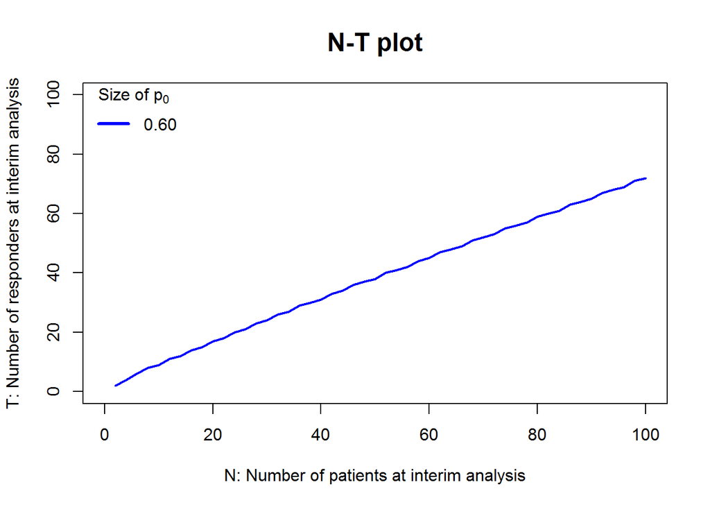

```r
NT_s = plotNT.sup(p0, M, q, alpha1)
```

```r
print(NT_s)
```

```
##         N  T  Z_score        P_val
##  [1,]   2  2      Inf 0.0000000000
##  [2,]   4  4      Inf 0.0000000000
##  [3,]   6  6      Inf 0.0000000000
##  [4,]   8  8      Inf 0.0000000000
##  [5,]  10  9 3.162278 0.0015654023
##  [6,]  12 11 3.968971 0.0000721838
##  [7,]  14 12 2.749545 0.0059677992
##  [8,]  16 14 3.326087 0.0008807432
##  [9,]  18 15 2.656313 0.0079000197
## [10,]  20 17 3.131121 0.0017414013
## [11,]  22 18 2.653300 0.0079709031
## [12,]  24 20 3.067246 0.0021604075
## [13,]  26 21 2.687112 0.0072072760
## [14,]  28 23 3.059298 0.0022185633
```

[output cut: 36 more lines]

### *2.3) For early stopping for futility*

The function `plotNT.fut` draws a N-T plot for early stopping for futility. If the observed $(N, T)$ plot is under the drawn line, we expect that the conditional power at that time would be less than `cp1`, and then unblinded analysis will be recommended for early stopping for futility of the new therapy.

When printing the function `plotNT.fut`, it gives a matrix names `N`, `T`, `Z_score` and `CP`. `CP` is the expected conditional power at the corresponding (N, T).

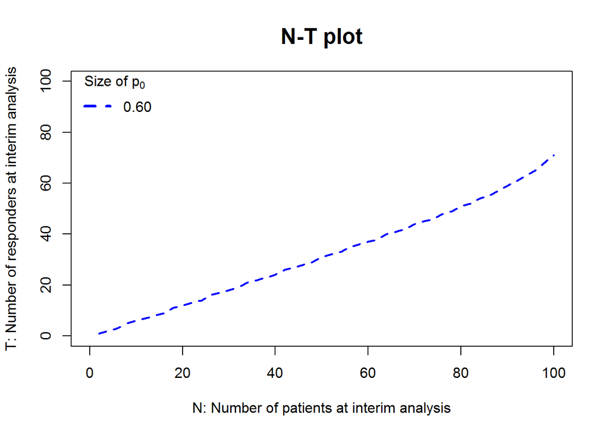

```r
NT_f = plotNT.fut(p0, M, q, alpha1, cp1)
```

### *2.4) For early stopping for superiority and futility with several candidate `p0`*

If the study investigators want to know possibilitiy of early stopping for superiority and futility, overlap two graphs via `par(new = T)`.

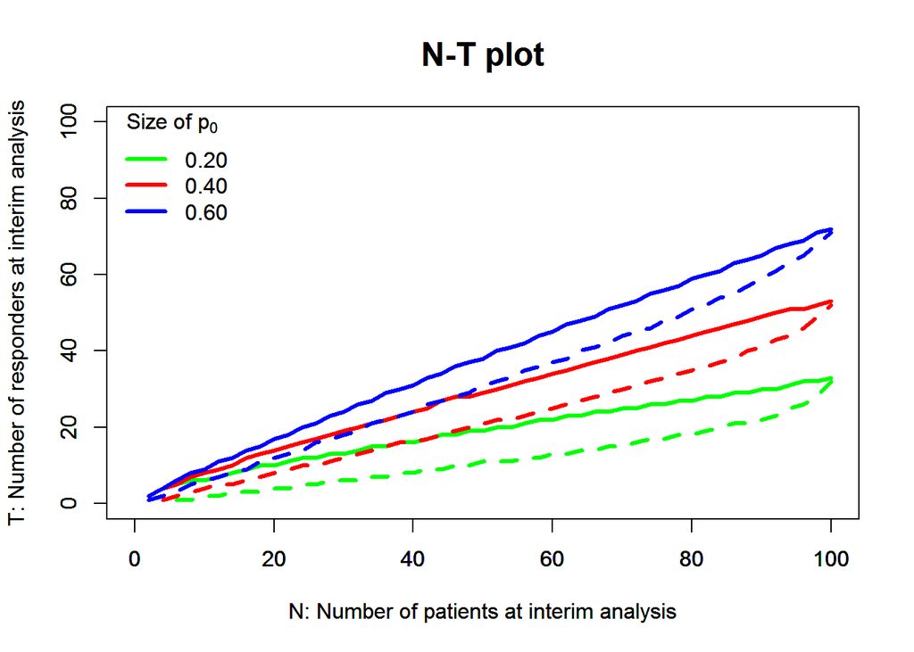

```r
NT_s3 = plotNT.sup(p0 = c(0.2, 0.4, 0.6), M, q, alpha1, col = c("green", "red", "blue"))
par(new = T)
NT_f3 = plotNT.fut(p0 = c(0.2, 0.4, 0.6), M, q, alpha1, cp1, col = c("green", "red", "blue"))
```

## 3. Conclusion

The tool serves a useful reference when interpreting the summary of the blinded data during the course of the trial. This can be used to determine whether or not the formal unblinded interim analysis should be conducted, without losing integrity of the study or spending any alpha. This tool will potentially save the study resource/budget by avoiding unnecessary interim analysis.